# Data Science with Tree Equity

presentation slides

Paityn Richardson & Jo Hardin

## 🌐 Why urban planning?

> Urban planning **IS** data science in action.

# HOW??

## What is data science??

> Data science is the practice of “uncover[ing] actionable insights hidden in data. These insights can be used to guide decision making and strategic planning.”<sup>1</sup>

**Examples:**

- 🎓 Schools study attendance and grade trends to identify students who may need extra support before they fall behind.
- 🏥 Hospitals use patient records and trends to predict who’s at risk for certain illnesses — helping doctors intervene earlier.
[^1]: https://www.ibm.com/think/topics/data-science

## DS cycle $\rightarrow$ urban planning cycle

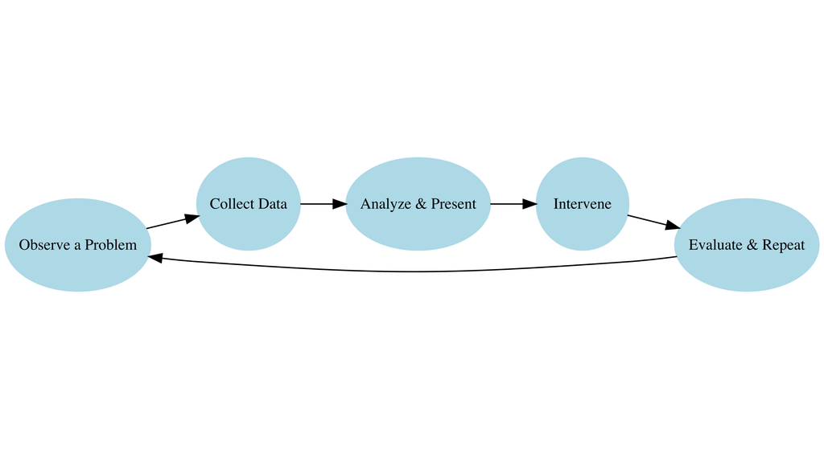

# 🌳 Introduction: Tree equity and city planning

- Tree planting is a direct action of city planning initiatives
  - *Why do some neighborhoods have fewer trees than others?*
  - *How do trees affect neighborhoods?*
  - *How can we use data to understand the relationship between urban canopy and other variables?*

## Urban forests: Tree Equity Score

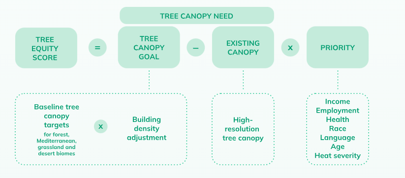

- Tree canopy coverage…
  - improves air quality and stabilizes environmental hazards
  - intercepts rainfall and prevents stormwater runoff
  - reduces heat extremity improving peoples’ physical and mental health

## Today’s goals

- Learn to use R for data analysis and communication
- Understand what makes a dataset meaningful
- Ask important questions about data and the observed world
- Explore how data can inform **just** and **sustainable** practices

# Working with data

In order to process the tree equity data, we first need to learn how to **wrangle** the data!

## Data wrangling

As a first step, we need to **prepare** the data.

**Data wrangling includes:**

- Cleaning messy or incomplete data
- Selecting the most relevant information
- Reshaping data into a usable form
- Creating new important variables

Think of it like *organizing your workspace before starting a project*.

## MathLink cubes

## `filter()`: keep certain rows

`filter()` keeps only the rows that meet specific conditions.

```r
cubes |>
  filter(red == "triangle")
```

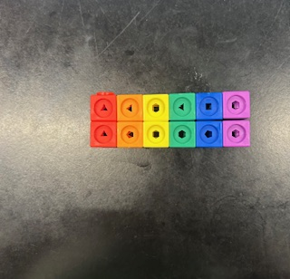

## MathLink cubes

## `select()`: keep certain columns

`select()` keeps only specified variables (columns).

```r
cubes |>
  select(red, green)
```

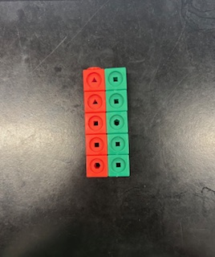

## MathLink cubes

## `mutate()`: add a new column

`mutate()` creates a new column (variable) by transforming existing ones.

```r
cubes |>
  mutate(white = case_when(
    blue == "hexagon" ~ "square",
    blue != "hexagon" ~ "triangle")
    )
```

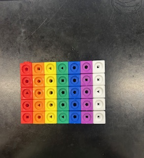

## `arrange()`: ordering the rows

`arrange()` sorts the rows by the values of a variable (ascending or descending).

```r
# Hexagon → Square → Triangle → Pentagon.
cubes |>
  arrange(purple)
```

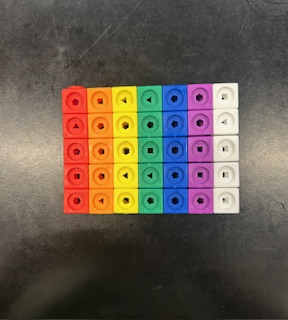

## `group_by()` and `summarize()`: summarizing by category

`group_by()` holds the rows in groups, specified by a particular variable.

`summarize()` collapses the rows so that there is **only one** row per group. A new variable is created to be the summary value.

```r
cubes |>
  group_by(yellow) |>
  summarize(count = n())
```

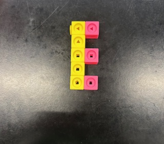

## A Look at the data

### California tree coverage data <sup>1</sup>

| GEOID | place | state | state_abbr | county | ua_name | ua_pop | congressio | cbg_pop | acs_pop | land_area | biome | cnpysource | tc_goal | treecanopy | tc_gap | priority_i | pctpoc | pctpocnorm | pctpov | pctpovnorm | unemplrate | unemplnorm | dep_ratio | dep_perc | depratnorm | linguistic | lingnorm | health_nor | temp_diff | … |
| --- | --- | --- | --- | --- | --- | --- | --- | --- | --- | --- | --- | --- | --- | --- | --- | --- | --- | --- | --- | --- | --- | --- | --- | --- | --- | --- | --- | --- | --- | --- |
| 060014001001 | Oakland | California | CA | Alameda County | San Francisco--Oakland, CA | 3,521,738.00 | CA Congressional District 13 | 1,789.00 | 1,963.00 | 3.50 | Mediterranean | Google | 0.30 | 0.60 | 0.00 | 0.31 | 0.27 | 0.27 | 0.12 | 0.12 | 0.02 | 0.05 | 0.86 | 0.46 | 0.43 | 0.00 | 0.00 | 0.26 | −5.75 | … |
| 060014001002 | Oakland | California | CA | Alameda County | San Francisco--Oakland, CA | 3,521,738.00 | CA Congressional District 13 | 1,249.00 | 1,361.00 | 1.21 | Mediterranean | Google | 0.30 | 0.46 | 0.00 | 0.34 | 0.34 | 0.34 | 0.09 | 0.09 | 0.05 | 0.10 | 0.77 | 0.43 | 0.38 | 0.00 | 0.00 | 0.26 | 1.32 | … |
| 060014002001 | Oakland | California | CA | Alameda County | San Francisco--Oakland, CA | 3,521,738.00 | CA Congressional District 13 | 1,022.00 | 1,029.00 | 0.29 | Mediterranean | Google | 0.30 | 0.28 | 0.02 | 0.31 | 0.21 | 0.21 | 0.05 | 0.05 | 0.04 | 0.08 | 1.01 | 0.50 | 0.51 | 0.00 | 0.00 | 0.25 | −2.10 | … |
| 060014002002 | Oakland | California | CA | Alameda County | San Francisco--Oakland, CA | 3,521,738.00 | CA Congressional District 13 | 979.00 | 1,009.00 | 0.30 | Mediterranean | Google | 0.30 | 0.31 | 0.00 | 0.32 | 0.38 | 0.38 | 0.13 | 0.13 | 0.10 | 0.19 | 0.45 | 0.31 | 0.22 | 0.00 | 0.00 | 0.25 | −3.20 | … |
| 060014003001 | Oakland | California | CA | Alameda County | San Francisco--Oakland, CA | 3,521,738.00 | CA Congressional District 13 | 1,123.00 | 1,122.00 | 0.27 | Mediterranean | Google | 0.30 | 0.22 | 0.08 | 0.31 | 0.34 | 0.34 | 0.04 | 0.04 | 0.03 | 0.05 | 0.56 | 0.36 | 0.28 | 0.03 | 0.03 | 0.30 | −0.31 | … |
| 060014003002 | Oakland | California | CA | Alameda County | San Francisco--Oakland, CA | 3,521,738.00 | CA Congressional District 13 | 1,528.00 | 1,623.00 | 0.27 | Mediterranean | Google | 0.25 | 0.21 | 0.04 | 0.33 | 0.44 | 0.44 | 0.08 | 0.08 | 0.05 | 0.09 | 0.41 | 0.29 | 0.20 | 0.03 | 0.03 | 0.30 | −0.11 | … |

Variable descriptions are given (mostly) at https://www.treeequityscore.org/methodology?tab=data-glossary

[^2]: Tree Equity Score. 2023. American Forests. https://www.treeequityscore.org/

## An observation

> Observational Unit: object by which data is collected and analyzed

For example, an observational unit could be any of the following:

- Person
- County
- State
- Country
- *What is the observational unit in the tree equity dataset?*

## What is the observational unit?

| GEOID | place | state | state_abbr | county | ua_name | ua_pop | congressio | cbg_pop | acs_pop | land_area | biome | cnpysource | tc_goal | treecanopy | tc_gap | priority_i | pctpoc | pctpocnorm | pctpov | pctpovnorm | unemplrate | unemplnorm | dep_ratio | dep_perc | depratnorm | linguistic | lingnorm | health_nor | temp_diff | … |
| --- | --- | --- | --- | --- | --- | --- | --- | --- | --- | --- | --- | --- | --- | --- | --- | --- | --- | --- | --- | --- | --- | --- | --- | --- | --- | --- | --- | --- | --- | --- |
| 060014001001 | Oakland | California | CA | Alameda County | San Francisco--Oakland, CA | 3,521,738.00 | CA Congressional District 13 | 1,789.00 | 1,963.00 | 3.50 | Mediterranean | Google | 0.30 | 0.60 | 0.00 | 0.31 | 0.27 | 0.27 | 0.12 | 0.12 | 0.02 | 0.05 | 0.86 | 0.46 | 0.43 | 0.00 | 0.00 | 0.26 | −5.75 | … |
| 060014001002 | Oakland | California | CA | Alameda County | San Francisco--Oakland, CA | 3,521,738.00 | CA Congressional District 13 | 1,249.00 | 1,361.00 | 1.21 | Mediterranean | Google | 0.30 | 0.46 | 0.00 | 0.34 | 0.34 | 0.34 | 0.09 | 0.09 | 0.05 | 0.10 | 0.77 | 0.43 | 0.38 | 0.00 | 0.00 | 0.26 | 1.32 | … |
| 060014002001 | Oakland | California | CA | Alameda County | San Francisco--Oakland, CA | 3,521,738.00 | CA Congressional District 13 | 1,022.00 | 1,029.00 | 0.29 | Mediterranean | Google | 0.30 | 0.28 | 0.02 | 0.31 | 0.21 | 0.21 | 0.05 | 0.05 | 0.04 | 0.08 | 1.01 | 0.50 | 0.51 | 0.00 | 0.00 | 0.25 | −2.10 | … |
| 060014002002 | Oakland | California | CA | Alameda County | San Francisco--Oakland, CA | 3,521,738.00 | CA Congressional District 13 | 979.00 | 1,009.00 | 0.30 | Mediterranean | Google | 0.30 | 0.31 | 0.00 | 0.32 | 0.38 | 0.38 | 0.13 | 0.13 | 0.10 | 0.19 | 0.45 | 0.31 | 0.22 | 0.00 | 0.00 | 0.25 | −3.20 | … |
| 060014003001 | Oakland | California | CA | Alameda County | San Francisco--Oakland, CA | 3,521,738.00 | CA Congressional District 13 | 1,123.00 | 1,122.00 | 0.27 | Mediterranean | Google | 0.30 | 0.22 | 0.08 | 0.31 | 0.34 | 0.34 | 0.04 | 0.04 | 0.03 | 0.05 | 0.56 | 0.36 | 0.28 | 0.03 | 0.03 | 0.30 | −0.31 | … |
| 060014003002 | Oakland | California | CA | Alameda County | San Francisco--Oakland, CA | 3,521,738.00 | CA Congressional District 13 | 1,528.00 | 1,623.00 | 0.27 | Mediterranean | Google | 0.25 | 0.21 | 0.04 | 0.33 | 0.44 | 0.44 | 0.08 | 0.08 | 0.05 | 0.09 | 0.41 | 0.29 | 0.20 | 0.03 | 0.03 | 0.30 | −0.11 | … |

- The GEOID or Census block Group describes a particular community or neighborhood in a given area contains between 600 - 3,000 people <sup>1</sup>
[^3]: American Forests Methods and Data Glossary. https://www.treeequityscore.org/methodology?tab=data-glossary

## What are the variables?

- `treecanopy`: actual tree coverage in an area
- `tc_goal`: ideal tree coverage based on needs
- `tc_gap`: how far behind the area is (`tc_goal` - `treecanopy`)
- `pctpocnorm`: % residents who are people of color
- `pctpovnorm`, `unemplnorm`: indicators of equity
- `lingnorm`: % of non-English households (linguistic isolation)
- `tes`: tree equity score (gap × need)

## Wrangling the tree data!

## 1. Keep certain rows

> Show only neighborhoods with low tree equity scores (`tes` $<$ 50).
- Hint: `filter()`

```r
ca_tes|>
  filter(tes < 50)
```

```
# A tibble: 578 × 39
   GEOID       place state state_abbr county ua_name ua_pop congressio
   <chr>       <chr> <chr> <chr>      <chr>  <chr>    <dbl> <chr>
 1 0600145010… Dubl… Cali… CA         Alame… Liverm… 240381 CA Congre…
 2 0600145075… Dubl… Cali… CA         Alame… Liverm… 240381 CA Congre…
 3 0600145075… Dubl… Cali… CA         Alame… Liverm… 240381 CA Congre…
 4 0600145120… Live… Cali… CA         Alame… Liverm… 240381 CA Congre…
 5 0600700370… Orov… Cali… CA         Butte… Orovil…  40190 CA Congre…
 6 0601330400… Byron Cali… CA         Contr… Discov…  15939 CA Congre…
 7 0601330400… Disc… Cali… CA         Contr… Discov…  15939 CA Congre…
 8 0601330720… Anti… Cali… CA         Contr… Antioc… 327378 CA Congre…
 9 0601331000… Pitt… Cali… CA         Contr… Antioc… 327378 CA Congre…
10 0601500010… Cres… Cali… CA         Del N… Cresce…  15620 CA Congre…
# ℹ 568 more rows
# ℹ 31 more variables: cbg_pop <dbl>, acs_pop <dbl>, land_area <dbl>,
#   biome <chr>, cnpysource <chr>, tc_goal <dbl>, treecanopy <dbl>,
#   tc_gap <dbl>, priority_i <dbl>, pctpoc <dbl>, pctpocnorm <dbl>,
#   pctpov <dbl>, pctpovnorm <dbl>, unemplrate <dbl>,
#   unemplnorm <dbl>, dep_ratio <dbl>, dep_perc <dbl>,
#   depratnorm <dbl>, linguistic <dbl>, lingnorm <dbl>, …
```

## 2. Keep certain columns

> Focus on `treecanopy`, `tes`, and `unemplnorm` (keep only those columns).
- Hint: `select()`

```r
ca_tes |>
  select(treecanopy, tes, unemplnorm)
```

```
# A tibble: 24,253 × 3
   treecanopy   tes unemplnorm
        <dbl> <dbl>      <dbl>
 1      0.598   100     0.0450
 2      0.458   100     0.100
 3      0.282    98     0.0756
 4      0.309   100     0.188
 5      0.22     94     0.0502
 6      0.208    96     0.0867
 7      0.191    90     0.0565
 8      0.195    96     0.0676
 9      0.323   100     0
10      0.258    96     0.0226
# ℹ 24,243 more rows
```

## 3. Create a new variable

> What percent of the tree coverage goal has been met?
- Hint: `mutate()`

[output not shown]

## 3. Create a new variable

> What percent of the tree coverage goal has been met?
- Hint: `mutate()`

```r
ca_tes |>
  mutate(pct_coverage_met = treecanopy / tc_goal * 100) |>
  select(GEOID, place, state, treecanopy, tc_goal, pct_coverage_met)
```

```
# A tibble: 24,253 × 6
   GEOID        place   state      treecanopy tc_goal pct_coverage_met
   <chr>        <chr>   <chr>           <dbl>   <dbl>            <dbl>
 1 060014001001 Oakland California      0.598    0.3             199.
 2 060014001002 Oakland California      0.458    0.3             152.
 3 060014002001 Oakland California      0.282    0.3              94.2
 4 060014002002 Oakland California      0.309    0.3             103.
 5 060014003001 Oakland California      0.22     0.3              73.3
 6 060014003002 Oakland California      0.208    0.25             83.0
 7 060014003003 Oakland California      0.191    0.3              63.6
 8 060014003004 Oakland California      0.195    0.25             78.1
 9 060014004001 Oakland California      0.323    0.25            129.
10 060014004002 Oakland California      0.258    0.3              86.0
# ℹ 24,243 more rows
```

## 4. Collapse the rows by values of a group

> Compute the average `tes` score by `place`
- Hint: `group_by()` and `summarise()`

```r
ca_tes |>
  group_by(place) |>
  summarize(avg_tes = mean(tes, na.rm = TRUE))
```

```
# A tibble: 874 × 2
   place        avg_tes
   <chr>          <dbl>
 1 Adelanto        54.6
 2 Agoura Hills    81.9
 3 Airport         43
 4 Alameda         87.5
 5 Alamo           99.2
 6 Albany          90.2
 7 Alhambra        73.0
 8 Aliso Viejo     85.7
 9 Alondra Park    65.7
10 Alpine          74.1
# ℹ 864 more rows
```

## 5. Which neighborhoods have the greatest tree equity need?

> Use only the variables `GEOID`, `place`, and `tes`.

**Hint:** Use `arrange()`

```r
ca_tes |>
  select(GEOID, place, tes) |>
  arrange(tes)
```

```
# A tibble: 24,253 × 3
   GEOID        place           tes
   <chr>        <chr>         <dbl>
 1 060310013001 Corcoran         13
 2 060650462002 Blythe           16
 3 060470003053 Livingston       17
 4 060290058042 Rosamond         18
 5 060150001012 Crescent City    19
 6 060670095033 Galt             20
 7 061070015023 Exeter           20
 8 060990002022 Oakdale          21
 9 060190071013 Selma            23
10 060230011022 Arcata           23
# ℹ 24,243 more rows
```

## 6. How does tree equity relate to both poverty and health disparity?

**Hint:** to sort *descending*, you’ll need to use `desc()` *within* the `arrange()` function.

```r
ca_tes |>
  mutate(combined_index = pctpov * health_nor) |>
  select(place, combined_index, tes) |>
  arrange(desc(combined_index))
```

```
# A tibble: 24,253 × 3
   place      combined_index   tes
   <chr>               <dbl> <dbl>
 1 Napa                1        69
 2 Chowchilla          0.997    61
 3 Hanford             0.920    26
 4 Wasco               0.908    37
 5 Shafter             0.903    58
 6 Arvin               0.899    24
 7 Delano              0.899    30
 8 Shafter             0.876    44
 9 Brawley             0.875    50
10 Rosamond            0.875    18
# ℹ 24,243 more rows
```

# Visualizing the data

## What and why

- Data visualization is the process of transforming raw data into visual formats, like **charts**, **graphs**, or **maps**, to make it easier to understand and interpret
- Communicate Results **Clearly** and **Effectively**
- Supports evidence-based decisions in fields like:
  - Public health
  - Climate research
  - Urban planning
  - Business & marketing

## What is **ggplot2**?

- **ggplot2** is an R package for data visualization
- Encoded functions for numerous different plot types
- Builds plots in layers using +

## Basic structure of a ggplot

```r
# General structure
data |>
  ggplot(aes(x = ..., y = ...)) +
  geom_function() +
  labs("label for you plot and axes")
```

## Common `geom()` functions

- geom_point(): scatter plot (x vs y)
- geom_bar(): bar charts (**categorical** data)
- geom_col(): bar chart with height from y variable (**categorical** data)
- geom_histogram(): distribution of numeric variable
- geom_line(): connect the dots across (x,y) coordinates

## Which plot should I use?

| variable type | plot type | `geom()`? | when to use |
| --- | --- | --- | --- |
| Categorical | bar chart | `geom_bar()` | Count frequency of categories |
| Numeric | histogram | `geom_histogram()` | Show distribution of one variables |
| Either + Either | scatter plot | `geom_point()` | Explore relationships between vars |
| Numeric + Either | line chart | `geom_line()` | Show change over x-variable |
| Category + Value | column chart | `geom_col()` | Compare totals across categories |

## Tree Equity vs. Poverty

> Is there a relationship between poverty and tree equity?

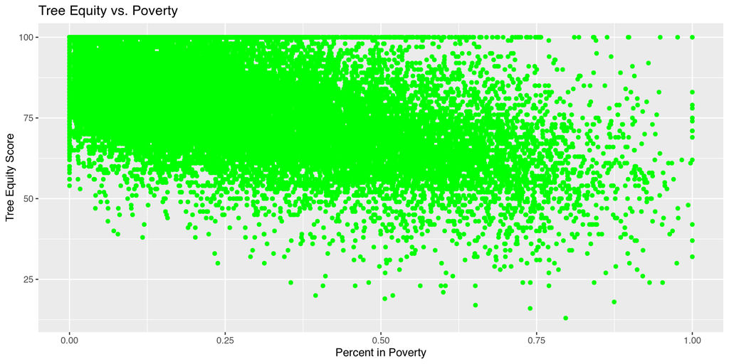

```r
ca_tes|>
  ggplot(aes(x = pctpov, y = tes)) +
  geom_point(color = "green") +
  labs(title = "Tree Equity vs. Poverty",
       x = "Percent in Poverty",
       y = "Tree Equity Score")
```

## Distribution of Tree Equity Scores

> How many places have each Tree equity score?

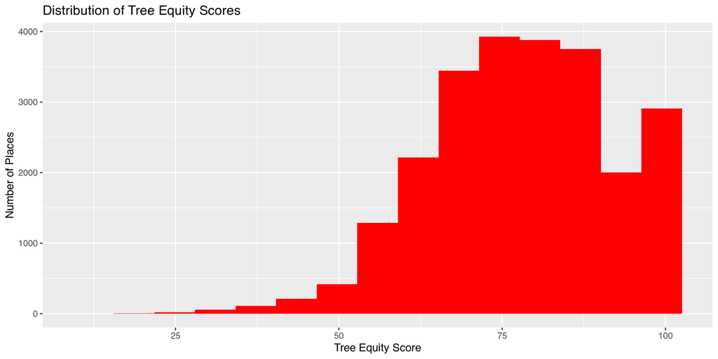

```r
ca_tes|>
  ggplot(aes(x = tes)) +
  geom_histogram(bins = 15, fill = "red") +
  labs(title = "Distribution of Tree Equity Scores",
       x = "Tree Equity Score",
       y = "Number of Places")
```

## Tree equity vs. linguistic isolation

> Is there a relationship between linnguistic isolation(`lingnorm`) and `tes` in an area.
- Use ggplot to plot the relationship between `tes` and `lingnorm`
- Choose the **best** plot for the variable types
- Create fitting labels for your axes and plot title

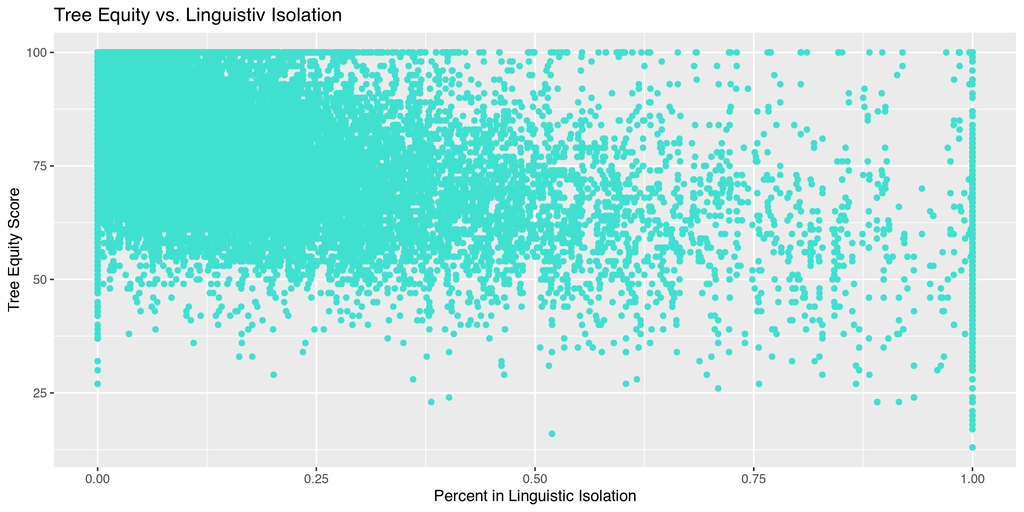

```r
ca_tes|>
  ggplot(aes(x = lingnorm, y = tes)) +
  geom_point(color = "turquoise") +
  labs(title = "Tree Equity vs. Linguistiv Isolation",
       x = "Percent in Linguistic Isolation",
       y = "Tree Equity Score")
```

# Explore, Analyze, Present!

## Your turn

> You will work in small groups to investigate tree equity in a new state(s)
- **Each Group Will:**
- Choose a research question(s)
- Use tidyverse tools to explore the data
- Create plot(s) with ggplot2
- Present findings to the class

## Your goals

- Clearly state your research question
- Support it with r code and graphs
- Use the data to identify a trend, pattern, or disparity
- Communicate **WHY** it matters

## Sample questions

- How does tree canopy vary across different neighborhoods in *chosen state*?
- Is there a relationship between percent in poverty and tree equity score in *chosen state*?
- How do tree equity trends compare between two or more *chosen states*?
- Are places with lower tree equity also more likely to have higher health disparities in *chosen state*?

## Getting the data

**Navigate to https://www.treeequityscore.org/:**

- in drop down menu, click the “methods and data” tab
- choose the “data download” page; you should see something like:

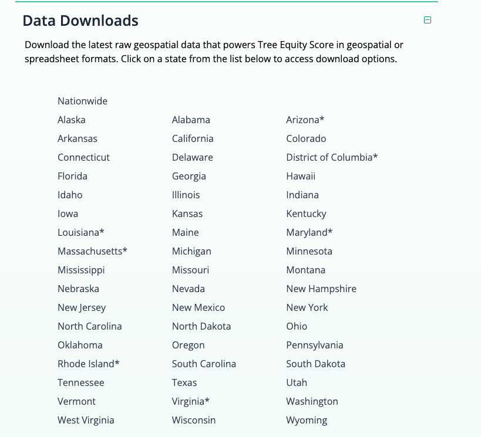

- by right-clicking on a state, you can get the URL, something like the following: https://tes-app-data-share.s3.amazonaws.com/nc/nc_csv.zip
- you may need to run the code below one line at a time to see what needs adjusting for your choice of state (likely you will **only** need to adjust the two digit state abbreviation).

## Uploading your own state data

```r
# Example code to load your state data
tmp <- tempfile(fileext = ".zip")
nc_data_zip <- download.file("https://tes-app-data-share.s3.amazonaws.com/nc/nc_csv.zip",
                             tmp, mode = "wb")

unzip(tmp, list = TRUE)
```

```
                 Name  Length                Date
1 data_dictionary.txt    4208 2025-07-01 11:20:00
2          nc_tes.csv 2373928 2025-07-01 11:20:00
```

```r
nc_tes <- readr::read_csv(unz(tmp, "nc_tes.csv"))

head(nc_tes)
```

```
# A tibble: 6 × 48
         GEOID place state state_abbr county ua_name ua_pop congressio
         <dbl> <chr> <chr> <chr>      <chr>  <chr>    <dbl> <chr>
1 370010201001 Burl… Nort… NC         Alama… Burlin… 147327 NC Congre…
2 370010201002 Burl… Nort… NC         Alama… Burlin… 147327 NC Congre…
3 370010201003 Burl… Nort… NC         Alama… Burlin… 147327 NC Congre…
4 370010201004 Burl… Nort… NC         Alama… Burlin… 147327 NC Congre…
5 370010202001 Burl… Nort… NC         Alama… Burlin… 147327 NC Congre…
6 370010202002 Burl… Nort… NC         Alama… Burlin… 147327 NC Congre…
# ℹ 40 more variables: cbg_pop <dbl>, acs_pop <dbl>, land_area <dbl>,
#   biome <chr>, cnpysource <chr>, tc_goal <dbl>, treecanopy <dbl>,
#   tc_gap <dbl>, priority_i <dbl>, pctpoc <dbl>, pctpocnorm <dbl>,
#   pctpov <dbl>, pctpovnorm <dbl>, unemplrate <dbl>,
#   unemplnorm <dbl>, dep_ratio <dbl>, dep_perc <dbl>,
#   depratnorm <dbl>, linguistic <dbl>, lingnorm <dbl>,
#   health_nor <dbl>, temp_diff <dbl>, temp_norm <dbl>, tes <dbl>, …
```